# mtcars example

Scott Smith

Friday, April 24, 2015

# Comparison of Statistical Learning Approaches for Fuel Efficiency

### Summary

This is an example of regression learning using R and the “mtcars” dataset provided with the R distribution. The objective is to develop an estimate of fuel consumption based on a number of features.

```r
data <- mtcars
summary(data)
```

```
##       mpg             cyl             disp             hp
##  Min.   :10.40   Min.   :4.000   Min.   : 71.1   Min.   : 52.0
##  1st Qu.:15.43   1st Qu.:4.000   1st Qu.:120.8   1st Qu.: 96.5
##  Median :19.20   Median :6.000   Median :196.3   Median :123.0
##  Mean   :20.09   Mean   :6.188   Mean   :230.7   Mean   :146.7
##  3rd Qu.:22.80   3rd Qu.:8.000   3rd Qu.:326.0   3rd Qu.:180.0
##  Max.   :33.90   Max.   :8.000   Max.   :472.0   Max.   :335.0
##       drat             wt             qsec             vs
##  Min.   :2.760   Min.   :1.513   Min.   :14.50   Min.   :0.0000
##  1st Qu.:3.080   1st Qu.:2.581   1st Qu.:16.89   1st Qu.:0.0000
##  Median :3.695   Median :3.325   Median :17.71   Median :0.0000
##  Mean   :3.597   Mean   :3.217   Mean   :17.85   Mean   :0.4375
##  3rd Qu.:3.920   3rd Qu.:3.610   3rd Qu.:18.90   3rd Qu.:1.0000
##  Max.   :4.930   Max.   :5.424   Max.   :22.90   Max.   :1.0000
##        am              gear            carb
##  Min.   :0.0000   Min.   :3.000   Min.   :1.000
##  1st Qu.:0.0000   1st Qu.:3.000   1st Qu.:2.000
##  Median :0.0000   Median :4.000   Median :2.000
##  Mean   :0.4062   Mean   :3.688   Mean   :2.812
##  3rd Qu.:1.0000   3rd Qu.:4.000   3rd Qu.:4.000
##  Max.   :1.0000   Max.   :5.000   Max.   :8.000
```

### Exploratory Data Analysis

Taking a look at cross plots of the first two features against the objective, it is clear there is some level of correlation between features and outcome (y). Displacement and power appear to be decently related to mpg, but it looks like there could be a 10 mpg swing for a given level of either feature.

```r
library(caret)
```

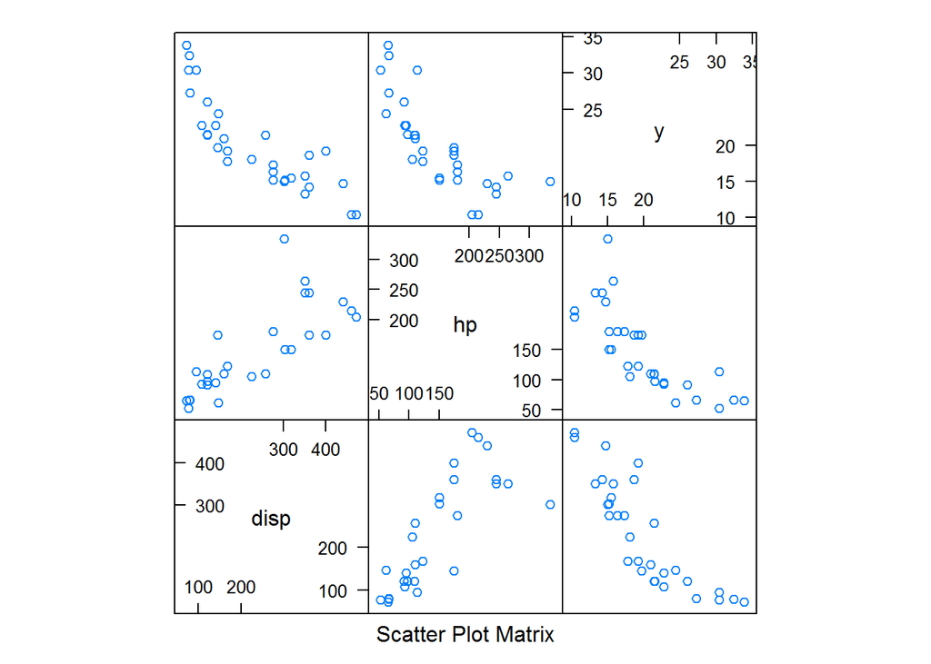

```r
featurePlot(data[,3:4],data[,1], plot = "pairs")
```

### Dataset Preparation

The inital dataset will be divided into a training set (75%) and a testing set (25%). The training set is used to build the predictive models and the testing set is used to gauge out-of-sample error and thereby, goodness of the model. Root-Mean Squared Error (RMSE) will be used as a metric to gauge goodness of the model.

```r
set.seed(3)
inTrain <- createDataPartition(data$mpg, p = 3/4, list = FALSE)
train <- data [inTrain,]; test <- data[-inTrain,]
```

### Simple Linear Model [mpg = f(displacement)]

Fitting a Linear Model for fuel efficiency as and calculating the RMSE on predictions for the testing set.

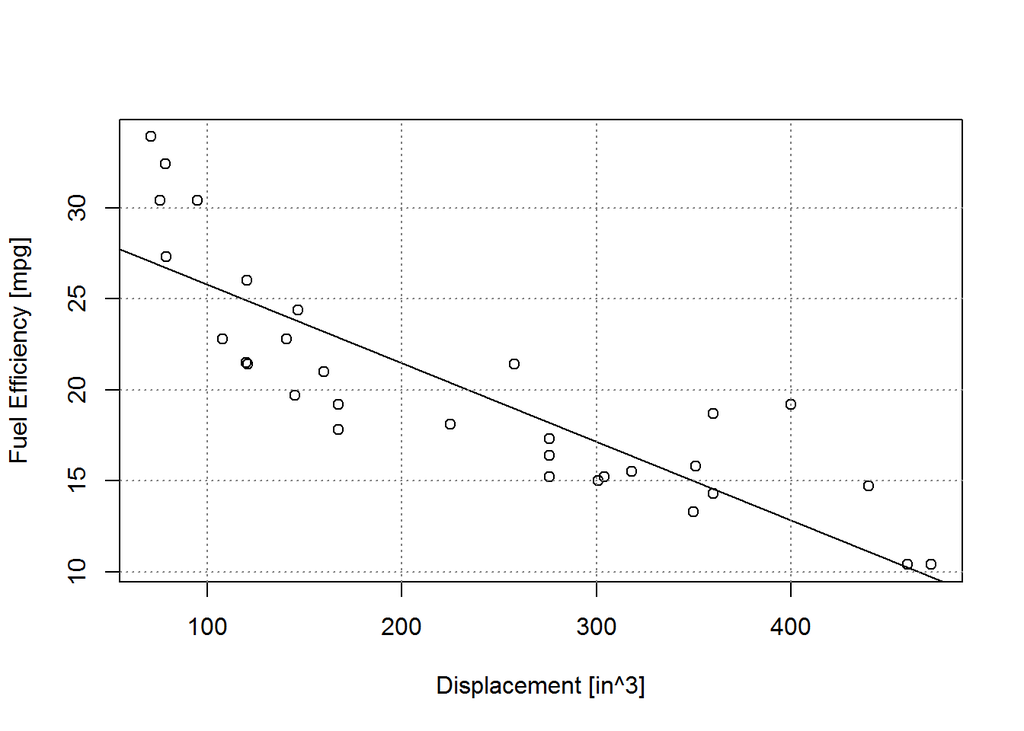

```r
lmFit <- lm(mpg ~ disp, data = train)

plot(data$disp, data$mpg, type = "p",
     xlab = "Displacement [in^3]",
     ylab = "Fuel Efficiency [mpg]")
abline(coefficients(lmFit)); grid(col = "gray50")
```

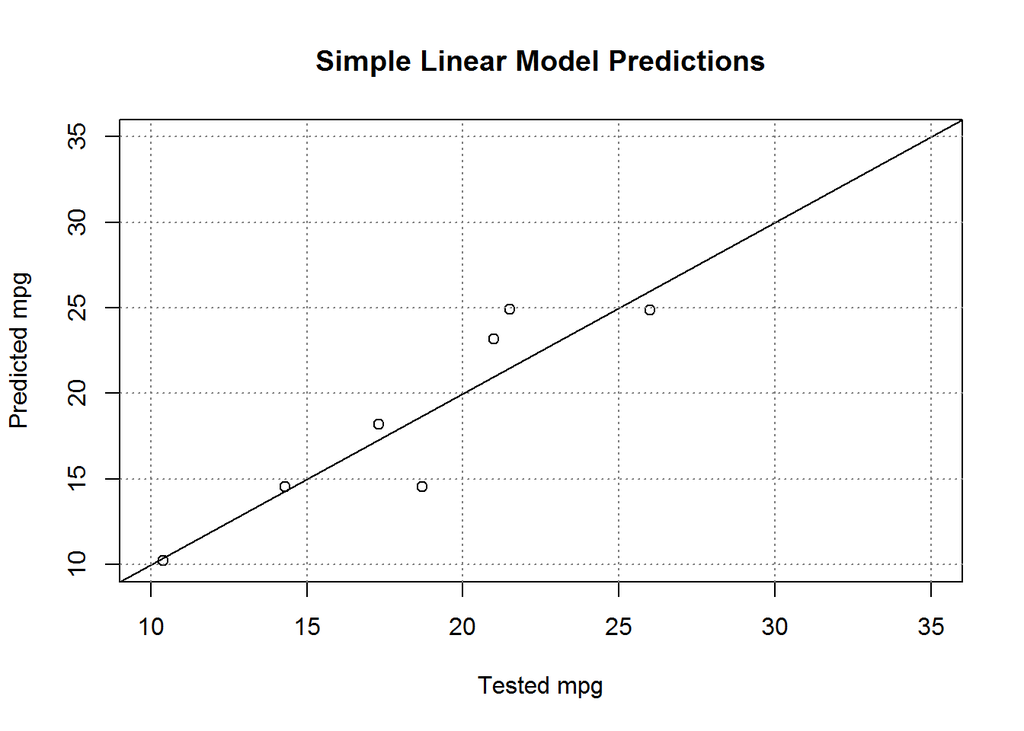

```r
lmPred <- predict(lmFit, test)
plot(test$mpg, lmPred, xlab = "Tested mpg", ylab = "Predicted mpg", xlim = c(10,35), ylim = c(10,35),
     main = "Simple Linear Model Predictions"); abline(0,1); grid(col = "gray50")
```

```r
lmRMSE <- (1/length(test$mpg)*sum((lmPred - test$mpg)^2))^.5
```

### Generalized Linear Model

Fitting a linear model combining all features and returning RMSE for test set predictions, as well as the individual coefficients.

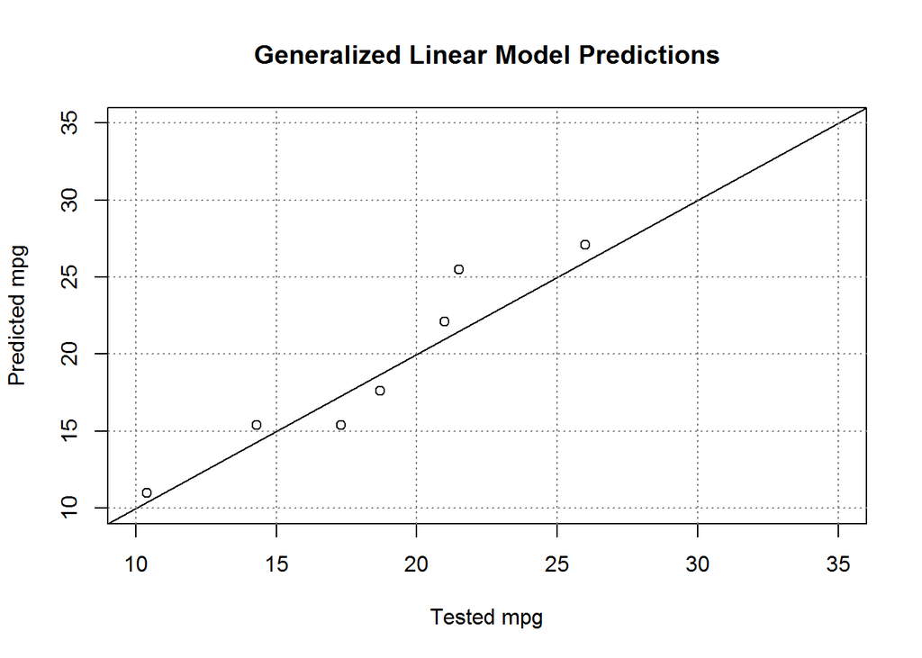

```r
glmFit <- train(mpg ~ ., data = train, method = "glm")
glmPred <- predict(glmFit, test)
plot(test$mpg, glmPred, xlab = "Tested mpg", ylab = "Predicted mpg", xlim = c(10,35), ylim = c(10,35),
     main = "Generalized Linear Model Predictions"); abline(0,1); grid(col = "gray50")
```

```r
glmRMSE <- (1/length(test$mpg)*sum((glmPred - test$mpg)^2))^.5
print(coef(glmFit$finalModel))
```

```
## (Intercept)         cyl        disp          hp        drat          wt
## 24.58107489 -1.15943231  0.01536284 -0.01368085  0.80608815 -4.02894114
##        qsec          vs          am        gear        carb
##  0.65420532 -0.50995964  1.67189732 -0.19694552 -0.01606113
```

### Support Vector Machine

Fitting a support vector machine and returning RMSE on predictions for the testing set.

```r
set.seed(5)
svmFit <- train(mpg ~ ., data = data, method = "svmLinear")
```

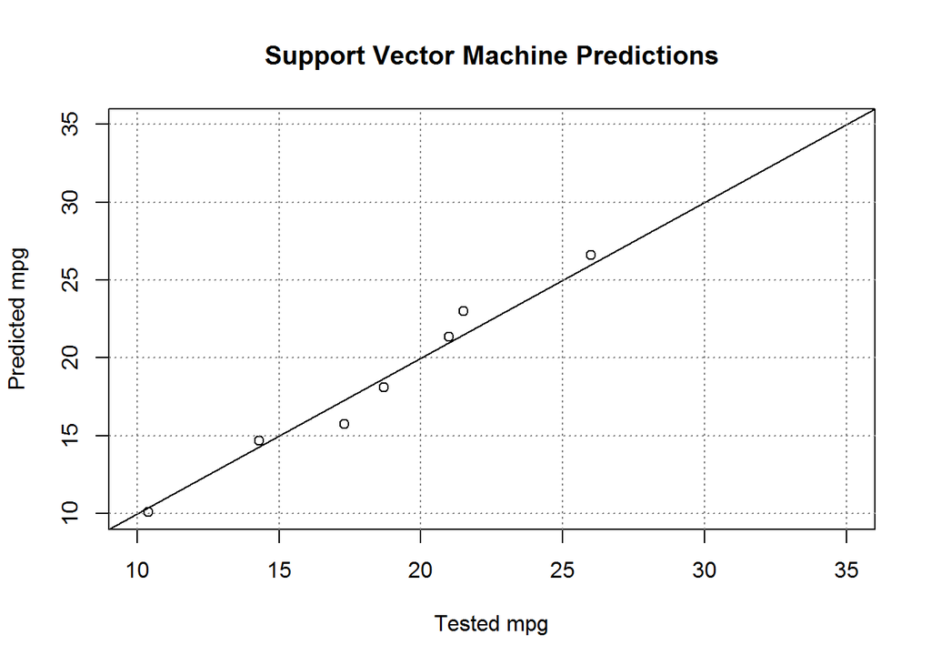

```r
svmPred <- predict(svmFit, test)
plot(test$mpg, svmPred, xlab = "Tested mpg", ylab = "Predicted mpg", xlim = c(10,35), ylim = c(10,35),
     main = "Support Vector Machine Predictions"); abline(0,1); grid(col = "gray50")
```

```r
svmRMSE <- (1/length(test$mpg)*sum((svmPred - test$mpg)^2))^.5
```

### Random Forest

Fitting a random forest and returning RMSE on predictions for the testing set.

```r
set.seed(7)
rfFit <- train(mpg ~ ., data = data, method = "rf")
```

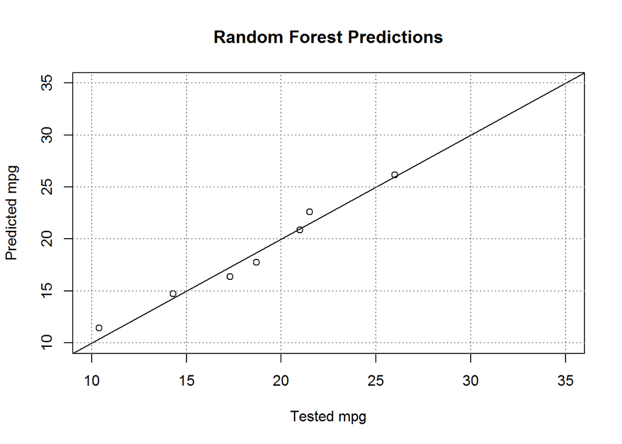

```r
rfPred <- predict(rfFit, test)
plot(test$mpg, rfPred, xlab = "Tested mpg", ylab = "Predicted mpg", xlim = c(10,35), ylim = c(10,35),
     main = "Random Forest Predictions"); abline(0,1); grid(col="gray50")
```

```r
rfRMSE <- (1/length(test$mpg)*sum((rfPred - test$mpg)^2))^.5
```

### Model Comparison

Finally, a comparison of root-mean squared errors for the four models.

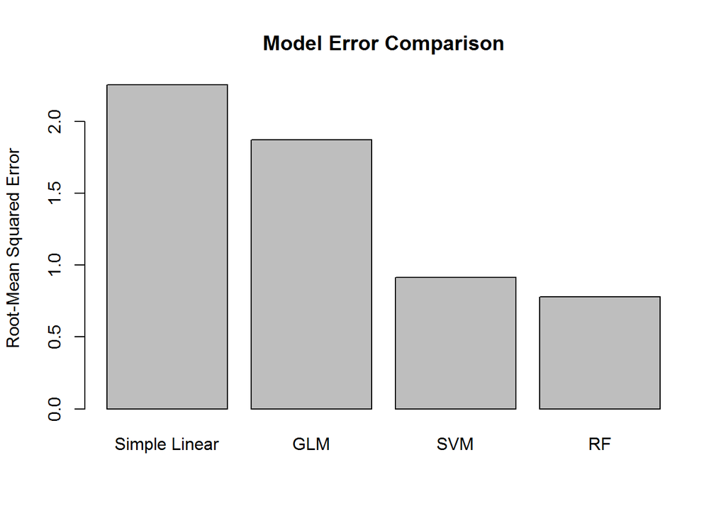

```r
barplot(c(lmRMSE, glmRMSE, svmRMSE, rfRMSE), horiz=FALSE,
  names.arg=c("Simple Linear", "GLM", "SVM", "RF"),
  ylab = "Root-Mean Squared Error", main = "Model Error Comparison")
```